# Google playstore analysis

## Eva He, Coworker:Karen Gao,Katherine Li,Sarah Xi, Zhijing Zhao

```r
library(tidyverse)
library(dplyr)
library(ggplot2)
library(fitdistrplus)
play_orig <- read.csv("D:/website/eeeeevahe.github.io/files/google/playStore5.csv")
play <- play_orig
str(play)
```

```
'data.frame':   8890 obs. of  13 variables:
 $ App           : Factor w/ 8044 levels "- Free Comics - Comic Apps",..: 3029 6775 4771 1759 2196 2014 540 1715 5723 2393 ...
 $ Category      : Factor w/ 34 levels "1.9","ART_AND_DESIGN",..: 2 32 8 17 6 31 8 22 13 16 ...
 $ Rating        : num  NA 4.5 4.3 5 4.5 5 4.4 4.2 4.8 NA ...
 $ Reviews       : Factor w/ 5062 levels "0","1","10","100",..: 4281 3439 2025 2 3789 2806 2347 1384 2152 1 ...
 $ Size          : Factor w/ 428 levels "1,000+","1.0M",..: 207 112 428 296 428 115 45 70 256 428 ...
 $ Installs      : Factor w/ 22 levels "0","0+","1,000,000,000+",..: 14 7 10 9 5 12 11 5 7 6 ...
 $ Type          : Factor w/ 4 levels "0","Free","NaN",..: 2 2 2 2 2 2 2 2 2 4 ...
 $ Price         : Factor w/ 79 levels "$0.99","$1.00",..: 78 78 78 78 78 78 78 78 78 1 ...
 $ Content.Rating: Factor w/ 7 levels "","Adults only 18+",..: 3 3 3 3 3 6 3 4 3 3 ...
 $ Genres        : Factor w/ 118 levels "Action","Action;Action & Adventure",..: 10 110 36 63 22 109 36 72 54 7 ...
 $ Last.Updated  : Factor w/ 1292 levels "1.0.19","April 1, 2016",..: 987 198 177 659 877 143 566 1239 177 599 ...
 $ Current.Ver   : Factor w/ 2508 levels "","0.0.0.2","0.0.1",..: 102 2046 2503 1777 2175 102 964 694 2503 2503 ...
 $ Android.Ver   : Factor w/ 35 levels "","1.0 and up",..: 10 22 35 19 15 15 19 19 35 35 ...
```

## Data Cleaning

```r
play <- play %>%
  # remove the duplicates and keep the only line with the highest number of reviews
  # first, show the results in a decreasing order for reviews
  arrange(desc(Reviews)) %>%

  # use distinct function to remove duplicate
  # set keep_all to true to show all columns
  distinct(App,.keep_all = TRUE) %>%

  # change it into the appropriate data type
  mutate(Rating = as.numeric(as.character(Rating)),
         Reviews = as.numeric(as.character(Reviews))) %>%

  # since we set ratings as dependent variable, we need to filter out the meaningless data with a NA rating
  # filter out those with non-numeric size
  # we find out that one line data is placed into the wrong column and need to filter it out
  # in the installs column, it has the 'free' character which should be in the Type column
  filter(Rating != "NA" & Reviews != 0 & Size != "Varies with device" & Installs != "Free") %>%

  # transform and group the 'installs' column
  # remove the coma using str_replace_all function
  mutate(Installs = str_replace_all(Installs, ",", ""))

# remove the plus sign using gsub function
play$Installs <- gsub("\\+", "", play$Installs)
# change into appropriate data type
play$Installs = as.numeric(as.character(play$Installs))

# regroup the Installs into 6 categories which have equal proportion
play$Installs[play$Installs == 1 | play$Installs == 5 | play$Installs == 10 | play$Installs == 50 | play$Installs == 100 | play$Installs == 500] <- "XXS"
play$Installs[play$Installs == 1000 | play$Installs == 5000] <- "XS"
play$Installs[play$Installs == 10000 | play$Installs == 50000] <- "S"
play$Installs[play$Installs == 100000 | play$Installs == 500000] <- "M"
play$Installs[play$Installs == 1000000] <- "L"
play$Installs[play$Installs == 5000000 | play$Installs == 10000000 | play$Installs == 50000000 | play$Installs == 100000000 | play$Installs == 500000000 | play$Installs == 1000000000] <- "XL"

play$Installs <- as.factor(play$Installs)

# remove the dollar sign in Price column
play$Price <- gsub("\\$", "", play$Price)
# change into appropriate data type
play$Price = as.numeric(as.character(play$Price))

# handle the Size column
# separate the Size into two column of the size number and unit(KB/MB)
play <- play %>%
  # because the format is the same as xxM / xxK, so separate from the first in the right hand
  separate(Size, c("size_num", "size_unit"), -1)
play$size_num <- as.numeric(as.character(play$size_num))
# we use ifelse function to transform KB to MB
play$size_num <- ifelse(play$size_unit == "k",
                        round(play$size_num/1024),
                        play$size_num)
# delete the unit column
play <- play[,-6]

# double check the structure of dataset
str(play)
```

```
'data.frame':   5814 obs. of  13 variables:
 $ App           : Factor w/ 8044 levels "- Free Comics - Comic Apps",..: 4175 6831 7553 2836 1444 3035 400 1501 7133 1031 ...
 $ Category      : Factor w/ 34 levels "1.9","ART_AND_DESIGN",..: 30 28 30 32 33 31 13 7 22 3 ...
 $ Rating        : num  4.2 4.2 4 4.7 4.3 4.3 4.6 4.5 4.7 4.5 ...
 $ Reviews       : num  9992 9975 9971 9971 9966 ...
 $ size_num      : num  31 18 33 22 5.5 10 3.7 38 97 2.9 ...
 $ Installs      : Factor w/ 6 levels "L","M","S","XL",..: 1 1 1 2 1 3 2 2 2 2 ...
 $ Type          : Factor w/ 4 levels "0","Free","NaN",..: 2 2 2 2 2 2 2 2 2 2 ...
 $ Price         : num  0 0 0 0 0 0 0 0 0 0 ...
 $ Content.Rating: Factor w/ 7 levels "","Adults only 18+",..: 3 3 3 6 3 3 6 4 3 3 ...
 $ Genres        : Factor w/ 118 levels "Action","Action;Action & Adventure",..: 103 97 103 110 114 109 52 34 72 14 ...
 $ Last.Updated  : Factor w/ 1292 levels "1.0.19","April 1, 2016",..: 959 480 764 198 868 1263 644 639 646 854 ...
 $ Current.Ver   : Factor w/ 2508 levels "","0.0.0.2","0.0.1",..: 2180 524 2232 459 433 1116 108 1795 1967 610 ...
 $ Android.Ver   : Factor w/ 35 levels "","1.0 and up",..: 19 21 27 27 7 17 17 19 19 19 ...
```

## Goal

We are trying to generate a predictive model for application developers to understand what factors will impact the overall rating of the application, and maybe make certain adjustments to their products. We picked rating as the dependent variable and by using some T-Test, Anova Test and linear regression model, we tested some of the possible independent variables which would affect the prediction of rating.

## T-TEST Rating ~ Type

For variables with two groups, we could use t-test to tell the mean difference between groups. As we want to test if there is a difference in rating between paid and free applications, we run a t test on ‘type’, which would tell the mean difference of rating for paid and free applications.

Hypothesis:

H0: There is no difference between free and paid applications on rating.

H1: There is a difference between free and paid applications on rating.

```r
t.test(play$Rating ~ play$Type, alternative = "two.side")
```

```
    Welch Two Sample t-test

data:  play$Rating by play$Type
t = -2.7924, df = 525.05, p-value = 0.005422
alternative hypothesis: true difference in means is not equal to 0
95 percent confidence interval:
 -0.13454089 -0.02341706
sample estimates:
mean in group Free mean in group Paid
          4.159347           4.238326
```

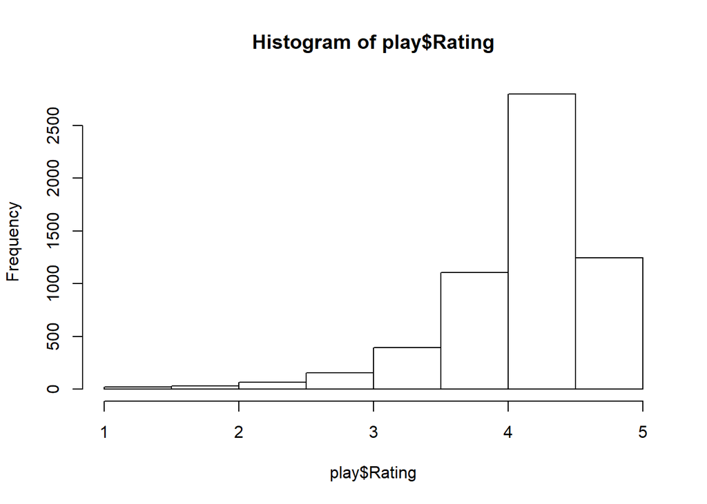

```r
hist(play$Rating)
```

Interpretation:

Limitation:

Something needs to be noticed is that even though we reject the null hypothesis, but it is up to 50% chance of incorrectly rejecting the null for the population with p-value of 0.05 and up to 15% chance for a p-value of 0.01. Another limitation includes the dependent variable is not normally distributed based on the histogram.

## ANOVA 1 Rating ~ Installs

After this data cleaning process, we run an ANOVA test to verify our hypothesis:

H0: There is no significant difference in ratings across the six groups with different levels of installations.

Ha: There exists some significant differences in ratings across the six groups with different levels of installations.

```r
summary(play_orig$Installs)
```

```
             0             0+ 1,000,000,000+     1,000,000+         1,000+
             1             13             50           1280            746
            1+    10,000,000+        10,000+            10+   100,000,000+
            55           1040            885            318            328
      100,000+           100+     5,000,000+         5,000+             5+
           948            591            606            399             71
   50,000,000+        50,000+            50+   500,000,000+       500,000+
           230            390            168             58            442
          500+           Free
           270              1
```

```r
installsModel = aov(Rating ~ Installs, data = play)
summary(installsModel)
```

```
              Df Sum Sq Mean Sq F value Pr(>F)
Installs       5   72.3  14.450    48.7 <2e-16 ***
Residuals   5808 1723.2   0.297
---
Signif. codes:  0 '***' 0.001 '**' 0.01 '*' 0.05 '.' 0.1 ' ' 1
```

```r
TukeyHSD(installsModel)
```

```
  Tukey multiple comparisons of means
    95% family-wise confidence level

Fit: aov(formula = Rating ~ Installs, data = play)

$Installs
               diff         lwr         upr     p adj
M-L    -0.090626714 -0.15782095 -0.02343248 0.0016990
S-L    -0.180539881 -0.24836699 -0.11271277 0.0000000
XL-L    0.070111839  0.00183594  0.13838774 0.0401466
XS-L   -0.180665996 -0.25271847 -0.10861353 0.0000000
XXS-L   0.133850326  0.04929816  0.21840249 0.0000953
S-M    -0.089913167 -0.15429024 -0.02553609 0.0009791
XL-M    0.160738553  0.09588881  0.22558829 0.0000000
XS-M   -0.090039282 -0.15885388 -0.02122468 0.0026588
XXS-M   0.224477040  0.14266653  0.30628755 0.0000000
XL-S    0.250651720  0.18514645  0.31615699 0.0000000
XS-S   -0.000126115 -0.06955882  0.06930659 1.0000000
XXS-S   0.314390207  0.23205910  0.39672131 0.0000000
XS-XL  -0.250777835 -0.32064901 -0.18090666 0.0000000
XXS-XL  0.063738487 -0.01896274  0.14643971 0.2391539
XXS-XS  0.314516322  0.22867081  0.40036184 0.0000000
```

Interpretation:

The resulting p-value appears really small, which implies that there exists a significant difference of ratings in at least one comparison pair between two groups of installation levels. We could reject the null hypothesis.

To find out exactly which comparison pairs showcase this significance difference. We then run a Tukey’s HSD test. We could see that the p-values for 13 out of 15 comparison pairs have small p-values. The p-values for pairs XXS-XL, and XS-S are large. Plus, the p-value for pair L-XL is quite close to the 0.05 cut-off. If we set our cut-off point to 0.01, this p-value will also be considered as large. In regard to the reason why differences between pair XXS-XL is not significant, it might be due to the nature of how ratings are generated. To elaborate, when apps have fewer installations, then fewer people would rate them, and thus the ratings are determined only by relatively smaller pools of people. When apps have more installations, then more people would rate them, and therefore the extreme values of ratings could more easily be evened out. In terms of the non-significant difference between pair XS-S, we need more information in order to explain this situation.

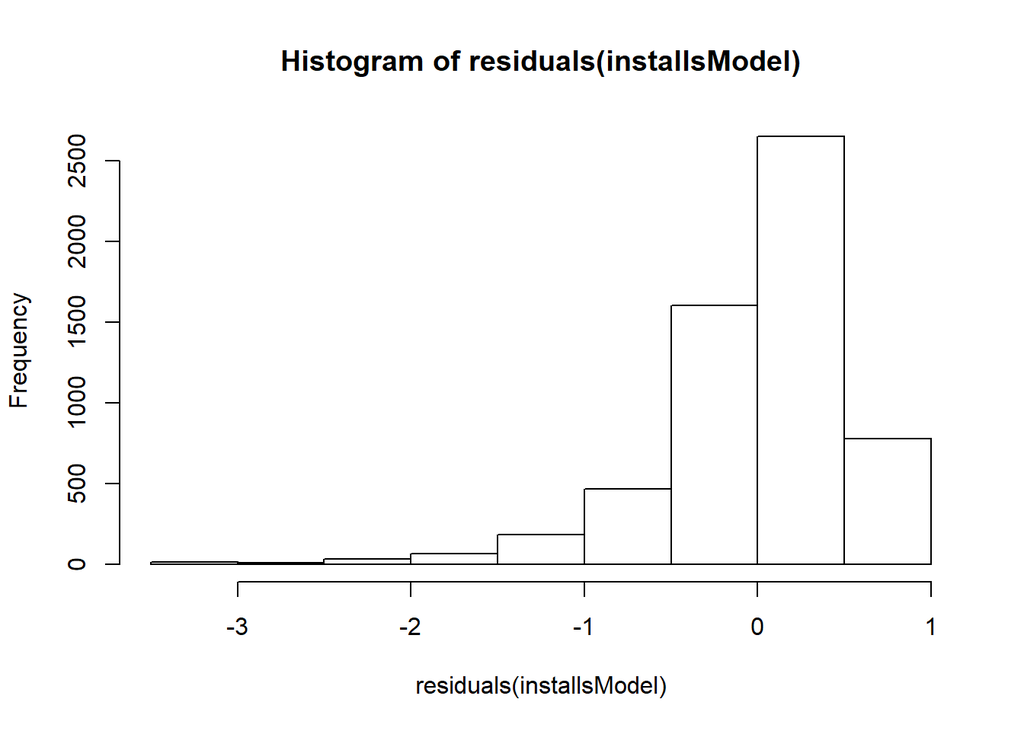

```r
hist(residuals(installsModel))
```

Limitation:

There are definitely limitations within our tests. One might be related to our approach of grouping different levels of installs into smaller groups. Though we have tried to have smaller groups that contain proportions of data that are as equivalent as possible, the amounts of data points included in each group still vary within a considerably large range. For instance, group “L” has 971 data points while group “M” has 1198 data points. This might affect our result to a certain extent.

Moreover, the residuals does not appear to be normally distributed - this opposes certain assumptions that ANOVA test is based on.

## Regression Model

After we get the result from T test and ANOVA, we decided to use Price, Number of reviews, Number of Installs and Paid Type to predict Rating.

Hypothesis #1:

H0: Price does not have an impact on Ratings

H1: Price has a negative impact on Ratings

Hypothesis #2:

H0: Number of installs does not have an impact on Ratings

H1: Number of installs has a positive impact on Ratings

Hypothesis #3:

H0: Size does not have an impact on Ratings

H1: Size has a positive impact on Ratings

Hypothesis #4:

H0: Payment type of application does not have an impact on Ratings

H1: Paid application has an impact on Ratings

Hypothesis #5:

H0: Reviews does not have an impact on Ratings

H1: Reviews has a negative impact on Ratings

Before we started, we build two graphs to find if there is any correlation between the variables.

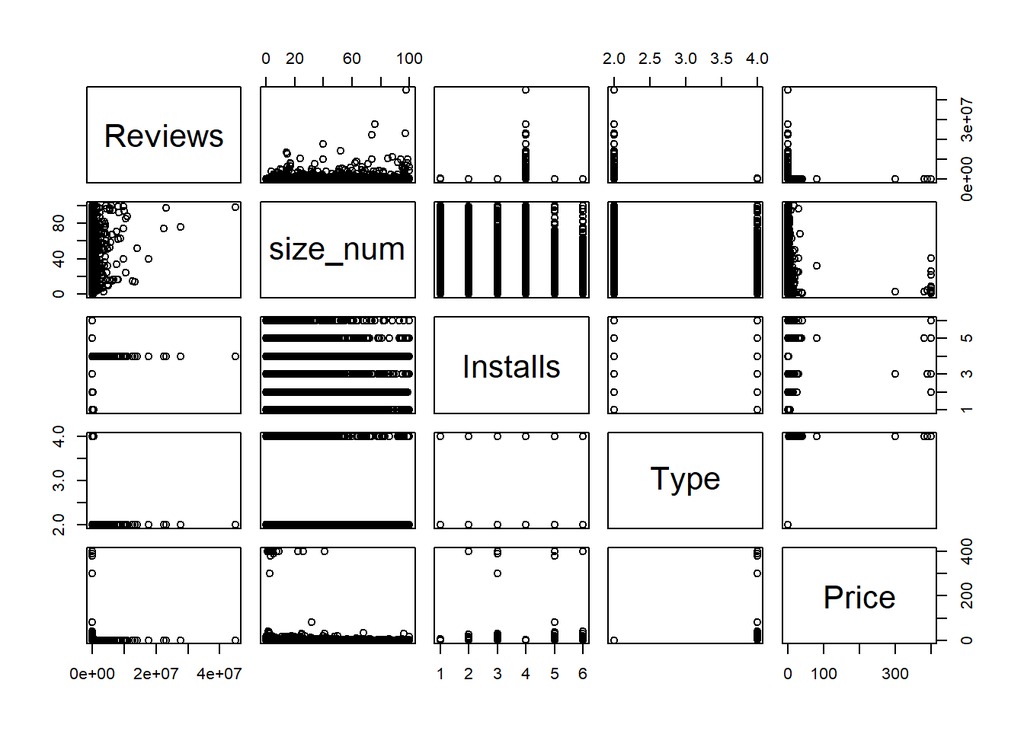

[output not shown]

[figure not shown]

```r
pairs(play[,4:8])
```

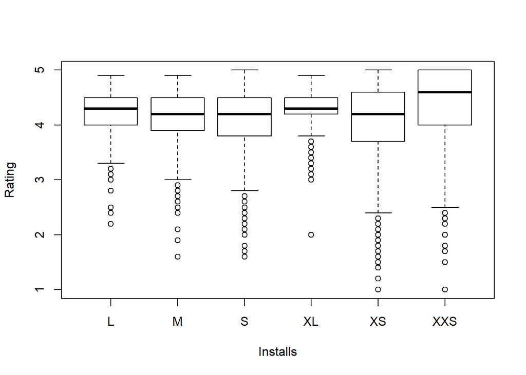

```r
boxplot(Rating ~ Installs, data = play)
```

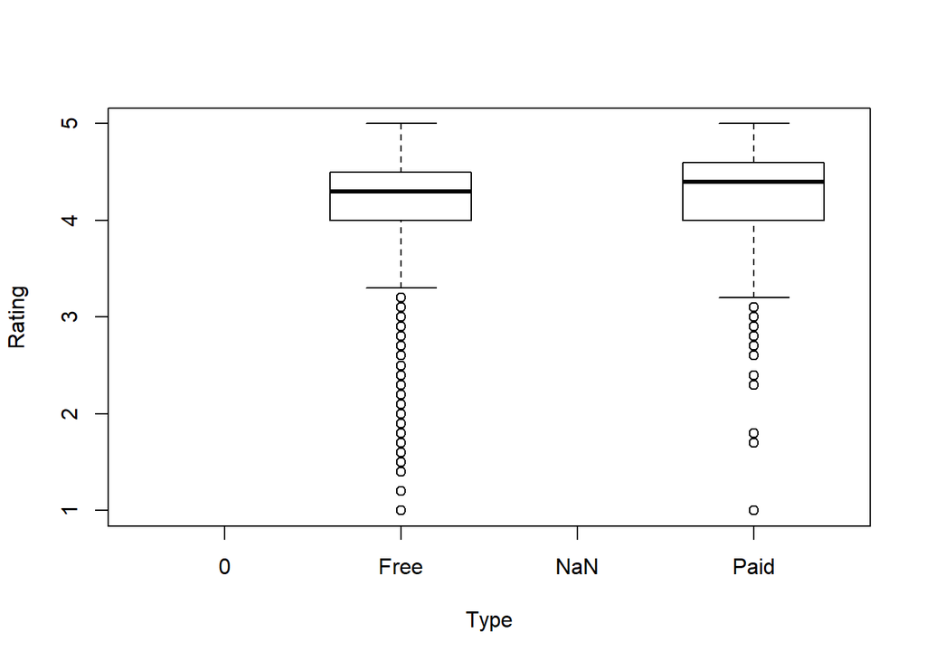

```r
boxplot(Rating ~ Type, data = play)
```

Interpretation:

By comparing the result from the box plot, we choose the category XL and category Free as our reference. Because the values within the category is more clustered than other categories and the difference is more obvious.

### train the model

```r
play$Installs <- relevel(play$Installs, ref='XL')
xyMod2 = lm(Rating ~ Price  + Installs + Type + size_num + Reviews, data = play)
summary(xyMod2)
```

```
Call:
lm(formula = Rating ~ Price + Installs + Type + size_num + Reviews,
    data = play)

Residuals:
    Min      1Q  Median      3Q     Max
-3.4577 -0.2153  0.0819  0.3535  0.9851

Coefficients:
              Estimate Std. Error t value Pr(>|t|)
(Intercept)  4.261e+00  2.010e-02 211.980  < 2e-16 ***
Price       -7.743e-04  3.671e-04  -2.109  0.03499 *
InstallsL   -5.421e-02  2.448e-02  -2.214  0.02685 *
InstallsM   -1.458e-01  2.358e-02  -6.185 6.62e-10 ***
InstallsS   -2.383e-01  2.421e-02  -9.843  < 2e-16 ***
InstallsXS  -2.468e-01  2.617e-02  -9.430  < 2e-16 ***
InstallsXXS  6.115e-02  3.067e-02   1.994  0.04620 *
TypePaid     1.303e-01  2.839e-02   4.589 4.55e-06 ***
size_num     4.731e-04  3.333e-04   1.419  0.15592
Reviews      1.917e-08  6.775e-09   2.830  0.00467 **
---
Signif. codes:  0 '***' 0.001 '**' 0.01 '*' 0.05 '.' 0.1 ' ' 1

Residual standard error: 0.5433 on 5804 degrees of freedom
Multiple R-squared:  0.0459,    Adjusted R-squared:  0.04442
F-statistic: 31.03 on 9 and 5804 DF,  p-value: < 2.2e-16
```

Interpretation:

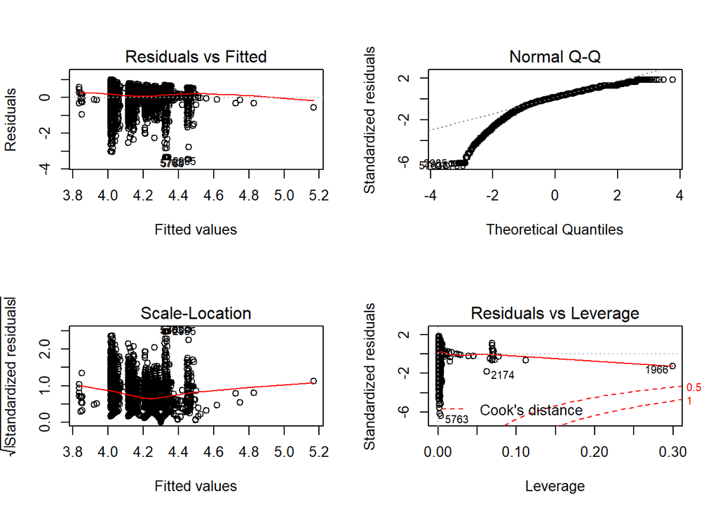

```r
par(mfrow = c(2, 2))
plot(xyMod2)
```

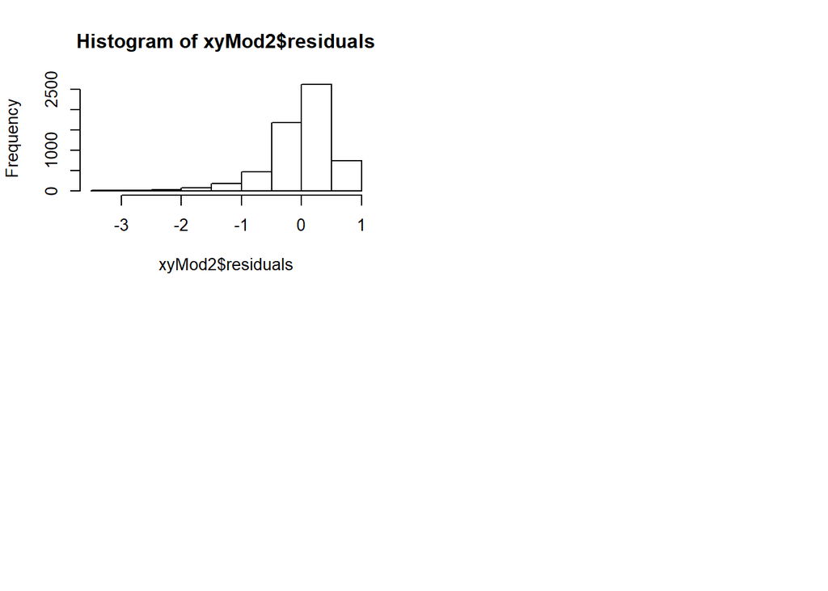

```r
hist(xyMod2$residuals)
```

Limitation:

The regression model needs to be further improved for better fit because it has the ability to predict but we can’t say that this is the best predictive model. The “Normal Q-Q” plot is saying that our errors are not normally-distributed so I draw a histogram to see the distribution directly. The residual vs leverage plot saying that our data have outliers problems.

The adjusted R-square is really close to 0 but the r-square is based on a context and can be improved so we can’t say for sure that the model is useless. The independent variables such as price have some outliers that may impact the fitness of regression greatly.

## ANOVA 2 Rating ~ Content.Rating

We are also curious about if there is any significant difference in ratings across groups of apps that are associated with different content ratings. In the original dataset there are one record with content rating left blank - this got cleaned out during our previous data preparation. Running summary on the sorted dataset, we detect there is only one record with content rating marked “unrated” - we decide to filter out this record for our following ANOVA test. Now we have content ratings categorized into five groups, which are “Adults only 18+”, “Everyone”, “Everyone 10+”, “Mature 17+” and “Teen”.

We run an ANOVA test for our hypothesis:

H0: There does not exist any significant difference in ratings among groups with different content ratings.

Ha: There are significant differences in ratings among the five groups with different content ratings.

```r
summary (play_orig$Content.Rating)
```

```
                Adults only 18+        Everyone    Everyone 10+      Mature 17+
              1               1            7152             344             427
           Teen         Unrated
            964               1
```

```r
summary (play$Content.Rating)
```

```
                Adults only 18+        Everyone    Everyone 10+      Mature 17+
              0               1            4706             221             265
           Teen         Unrated
            620               1
```

```r
play3 <- play %>%
  filter(Content.Rating != "Unrated")
contentModel = aov(Rating ~ Content.Rating, data = play3)
summary(contentModel)
```

```
                 Df Sum Sq Mean Sq F value   Pr(>F)
Content.Rating    4    6.5   1.636   5.313 0.000287 ***
Residuals      5808 1788.9   0.308
---
Signif. codes:  0 '***' 0.001 '**' 0.01 '*' 0.05 '.' 0.1 ' ' 1
```

```r
TukeyHSD(contentModel)
```

```
  Tukey multiple comparisons of means
    95% family-wise confidence level

Fit: aov(formula = Rating ~ Content.Rating, data = play3)

$Content.Rating
                                    diff         lwr         upr     p adj
Everyone-Adults only 18+     -0.34392265 -1.85843051  1.17058521 0.9720035
Everyone 10+-Adults only 18+ -0.25384615 -1.77161538  1.26392308 0.9910740
Mature 17+-Adults only 18+   -0.40490566 -1.92210720  1.11229588 0.9500072
Teen-Adults only 18+         -0.26193548 -1.77750321  1.25363224 0.9898876
Everyone 10+-Everyone         0.09007650 -0.01415394  0.19430694 0.1271422
Mature 17+-Everyone          -0.06098301 -0.15659192  0.03462590 0.4091184
Teen-Everyone                 0.08198717  0.01728718  0.14668715 0.0049780
Mature 17+-Everyone 10+      -0.15105951 -0.28901038 -0.01310863 0.0235957
Teen-Everyone 10+            -0.00808933 -0.12672940  0.11055074 0.9997328
Teen-Mature 17+               0.14297018  0.03182817  0.25411219 0.0041228
```

Interpretation:

The p-value from ANOVA is small - sufficient for us to reject the null. We could conclude that there exist certain significant differences in ratings among the five groups with different content ratings. To explore about exactly which comparison pairs showcase the significant difference, we run a Tukey HSD test.

From the results of the Tukey test, we could clearly see that only the p-values for pair Teen-Everyone, Teen-Mature 17+, and Mature 17+ - Everyone 10+ are small enough to imply the significance of differences. This is based on the scenario if we set the cut-off point for p-value to 0.05. If we set the cut-off point to 0.01, the difference of average rating between the two groups in the last pair would not be considered as significant. One implication from this result could be that the main users of teen apps are teens. And most likely, whoever rate those apps are teens as well. Teens might not be as critical as older people when it comes to rating an app. They might not have that many expectations or requests as older people normally do. So the average rating for teen apps would be higher than the average ratings for both Mature 17+ and Everyone apps. This could also be supported by the fact that p-value for Teen-Mature 17+ is 0.0041228, which is slightly smaller than the p-value for Teen-Everyone. Since a majority of the users rating the Mature 17+ apps would be people over 17, it is quite reasonable that the differences between the former pair would be moderately more significant.

Limitation:

## ANOVA 3 Rating ~ Category

In real life, in order to make informational decisions, people usually start from the highest level and then go into details for more exploration. And since we already identified that there is at least one significant difference across categories, we want to know that from a higher level, the rating of which broader group is most distinct from all others. Based on our understanding of the apps and personal experiences, we manually created four broader groups: Entertainment, Education, Tool, and Living. We then conducted a ANOVA and Tukey test to test our hypothesis.

Hypothesis:

H0: the average rating is the same across all four groups

Ha: the average rating is not the same across all four groups

```r
play2 <- play

play2$Category = as.character(play2$Category)

play2$Category[play2$Category == "ART_AND_DESIGN" | play2$Category == "SPORTS" | play2$Category == "COMICS" | play2$Category == "ENTERTAINMENT" | play2$Category == "GAME" | play2$Category == "SPORTS" | play2$Category == "SHOPPING" | play2$Category == "TRAVEL_AND_LOCAL" | play2$Category == "VIDEO_PLAYERS" | play2$Category == "SOCIAL" | play2$Category == "PHOTOGRAPHY" | play2$Category == "PERSONALIZATION" | play2$Category == "DATING" | play2$Category == "BEAUTY" | play2$Category == "AUTO_AND_VEHICLES"] <- "ENTERTAINMENT"

play2$Category[play2$Category == "BOOKS_AND_REFERENCE" | play2$Category == "NEWS_AND_MAGAZINES" | play2$Category == "EDUCATION" | play2$Category == "BUSINESS" | play2$Category == "PRODUCTIVITY" | play2$Category == "FINANCE" | play2$Category == "LIBRARIES_AND_DEMO"] <- "EDUCATION"

play2$Category[play2$Category == "TOOLS" | play2$Category == "MAPS_AND_NAVIGATION" | play2$Category == "COMMUNICATION"] <-  "TOOL"

play2$Category[play2$Category == "HOUSE_AND_HOME" | play2$Category == "PARENTING" | play2$Category == "MEDICAL" | play2$Category == "FAMILY" | play2$Category == "LIFESTYLE" | play2$Category == "WEATHER" | play2$Category == "EVENTS" | play2$Category == "FOOD_AND_DRINK" | play2$Category == "HEALTH_AND_FITNESS"] <-  "LIVING"
```

```r
categoryModel = aov(Rating ~ Category, data = play2)
summary(categoryModel)
```

```
              Df Sum Sq Mean Sq F value   Pr(>F)
Category       3   18.1   6.042   19.75 9.84e-13 ***
Residuals   5810 1777.3   0.306
---
Signif. codes:  0 '***' 0.001 '**' 0.01 '*' 0.05 '.' 0.1 ' ' 1
```

```r
TukeyHSD(categoryModel)
```

```
  Tukey multiple comparisons of means
    95% family-wise confidence level

Fit: aov(formula = Rating ~ Category, data = play2)

$Category
                                diff         lwr         upr     p adj
ENTERTAINMENT-EDUCATION  0.029941843 -0.02591335  0.08579703 0.5135141
LIVING-EDUCATION         0.020241221 -0.03550831  0.07599075 0.7871030
TOOL-EDUCATION          -0.145377981 -0.21541398 -0.07534198 0.0000006
LIVING-ENTERTAINMENT    -0.009700622 -0.05388629  0.03448505 0.9426671
TOOL-ENTERTAINMENT      -0.175319823 -0.23655221 -0.11408744 0.0000000
TOOL-LIVING             -0.165619202 -0.22675522 -0.10448319 0.0000000
```

Interpretation:

Based on our results, we identified that TOOL category overall has the most significant difference from the other three categories and its apps have the lowest average rating. We believe that one of the reasons for this pattern is that tools (which includes communication and maps & navigation) are the most commonly used apps on a daily basis so people generally will be more critical and have higher expectations on the functionality of these apps.

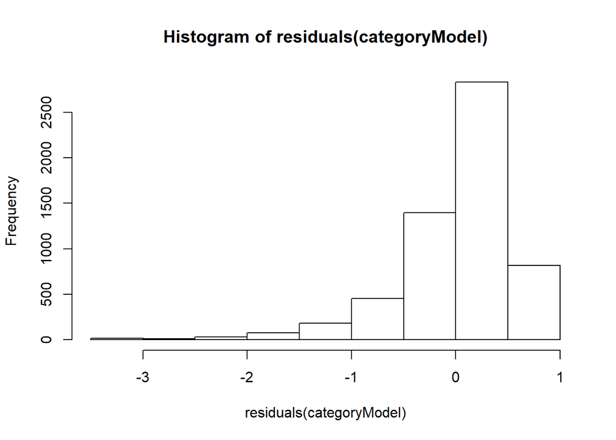

```r
hist(residuals(categoryModel))
```

```r
library(car)
leveneTest(Rating ~ Category, data = play)
```

```
## Levene's Test for Homogeneity of Variance (center = median)
##         Df F value    Pr(>F)
## group   32  6.3461 < 2.2e-16 ***
##       5781
## ---
## Signif. codes:  0 '***' 0.001 '**' 0.01 '*' 0.05 '.' 0.1 ' ' 1
```

Limitation:

Our classification of the categories is highly biased and different methods of classification might lead to different results.

Additionally, there are multiple assumptions on One-Way Anova test: errors are independent, errors are normally distributed, variances are homogeneous, and additivity of model effects. We ran some examinations to test the second and third assumptions. From the residual histogram, we can see that the residuals are not normally distributed and the distribution is skewed to the left, which means that the normality assumption in this analysis is not met. Furthermore, the p-value resulted from the Levene’s Test is significant. Thus the null hypothesis is rejected and we concluded that the variances are not homogeneous. The failure to meet the assumptions of Anova test is one of the limitations for this analysis.

## decision tree

### data preperation

change the size of L and XL into 1 which means this app will be a hit and others to 0 which means this app will less likely to be a hit.

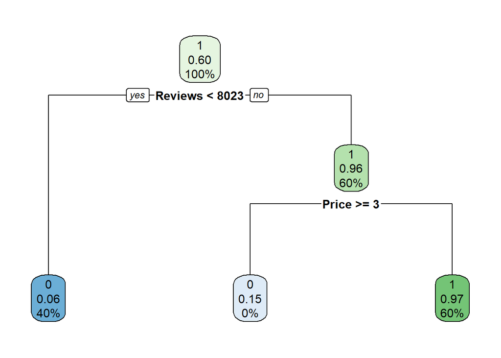

```r
library(rpart)
library(rpart.plot)
library(DMwR)
playmodel <- play %>%
  mutate(Installs = ifelse((Installs=="L")| (Installs=="XL"),1,0),
         Installs = as.factor(Installs),
         Rating = as.factor(Rating)) %>%
  dplyr::select(-Current.Ver,-Android.Ver,-Last.Updated,-App)

set.seed(1234)
sample_set <- sample(nrow(playmodel), round(nrow(playmodel)*.7), replace = FALSE)
play_train <- playmodel[sample_set, ]
play_test <- playmodel[-sample_set, ]
# Generate new balanced training data.
set.seed(1234)
play_train <- SMOTE(Installs ~ ., play_train, perc.over = 200, perc.under =100)

tree_mod <-
  rpart(
    Installs ~ .,
    method = "class",
    data = play_train,
    control = rpart.control(cp = 0.005)
  )

# Plot the decision tree using the rpart.plot() function from the rpart.plot library.
rpart.plot(tree_mod)
```

```r
# evaluate
tree_pred <- predict(tree_mod, play_test,  type = "class")

# Using our predictions, we can construct a Confusion Matrix.
tree_pred_table <- table(play_test$Installs, tree_pred)
tree_pred_table
```

```
##    tree_pred
##        0    1
##   0 1047   39
##   1   56  602
```

```r
# What is our accuracy?
tree_pred_accuracy <- sum(diag(tree_pred_table)) / nrow(play_test)
tree_pred_accuracy
```

```
## [1] 0.9455275
```

The accuracy of the tree is 94%.

A work by [Eva He](https://github.com/eeeeevahe)

*yhe24@nd.edu*